# Hopping of CBS-Sox2P constructs from LP-116kb

### 3xCBS_Sox2P_Fw

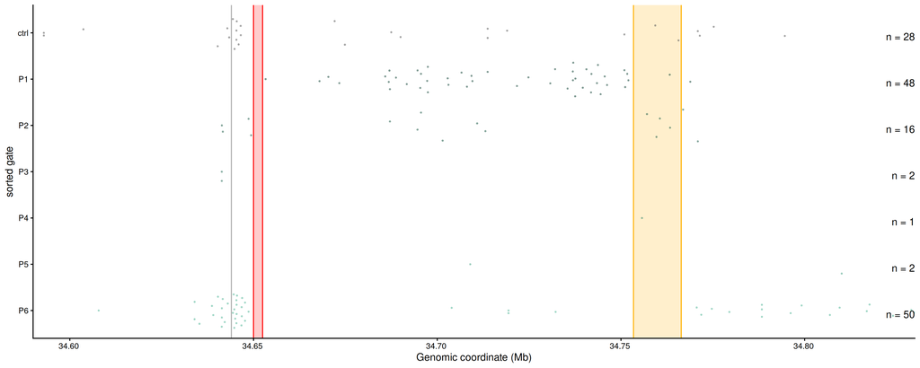

```r
all_exp = unique(tib_filtered_curated_strict$experiment)

#Rep 1
p23_MK01_bs_rep1 =
plot_beeswarm_only(TIB = tib_filtered_curated_strict %>%
                   filter(hopped & chr == "chr3" & replicate == "rep1" & population != "P0") %>% droplevels(),
                   EXP = all_exp,
                   CL = "23_MK01_C5",
                   PLOT_ANNOT = T,
                   PLOT_CTCF = F,
                   P_RANGE = prange_zoom_paper,
                   POINT_SIZE = 1.5)
p23_MK01_bs_rep1
```

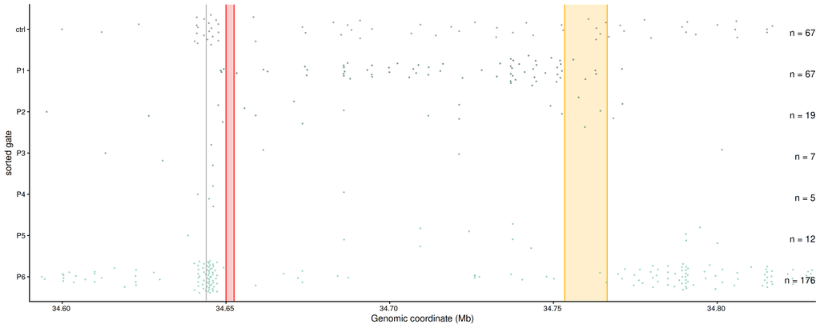

```r
#Rep 2
p23_MK01_bs_rep2 =
plot_beeswarm_only(TIB = tib_filtered_curated_strict %>%
                   filter(hopped & chr == "chr3" & replicate == "rep2" & population != "P0") %>% droplevels(),
                   EXP = all_exp,
                   CL = "23_MK01_C5",
                   PLOT_ANNOT = T,
                   PLOT_CTCF = F,
                   P_RANGE = prange_zoom_paper,
                   POINT_SIZE = 1.5)
p23_MK01_bs_rep2
```

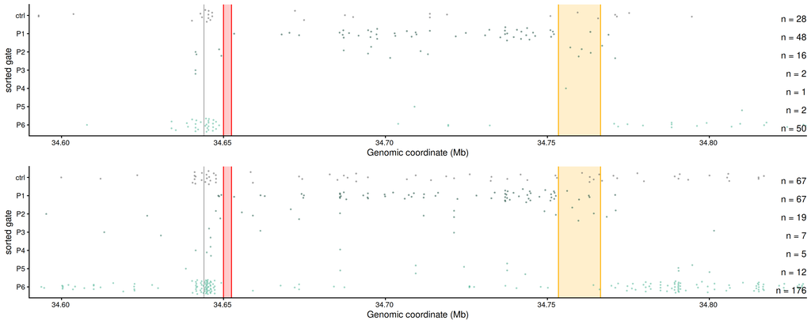

```r
plot_grid(p23_MK01_bs_rep1, p23_MK01_bs_rep2, ncol = 1)
```

### 3xCBS_Sox2P_Rv

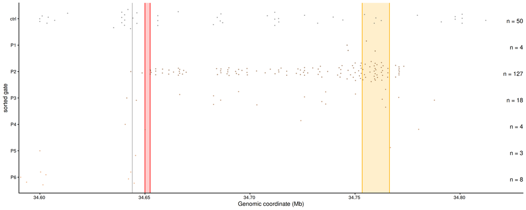

```r
all_exp = unique(tib_filtered_curated_strict$experiment)

#Rep 1
p23_MK02_bs_rep1 =
plot_beeswarm_only(TIB = tib_filtered_curated_strict %>%
                   filter(hopped & chr == "chr3" & replicate == "rep1" & population != "P0") %>% droplevels(),
                   EXP = all_exp,
                   CL = "23_MK02_C2",
                   PLOT_ANNOT = T,
                   PLOT_CTCF = F,
                   P_RANGE = prange_zoom_paper,
                   POINT_SIZE = 1.5)
p23_MK02_bs_rep1
```

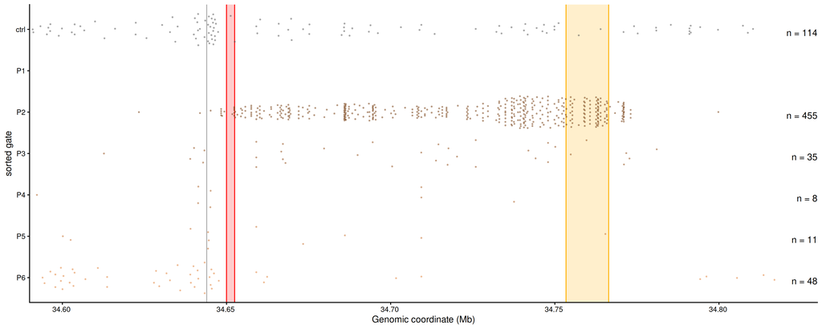

```r
#Rep 2
p23_MK02_bs_rep2 =
plot_beeswarm_only(TIB = tib_filtered_curated_strict %>%
                   filter(hopped & chr == "chr3" & replicate == "rep2" & population != "P0") %>% droplevels(),
                   EXP = all_exp,
                   CL = "23_MK02_C2",
                   PLOT_ANNOT = T,
                   PLOT_CTCF = F,
                   P_RANGE = prange_zoom_paper,
                   POINT_SIZE = 1.5)
p23_MK02_bs_rep2
```

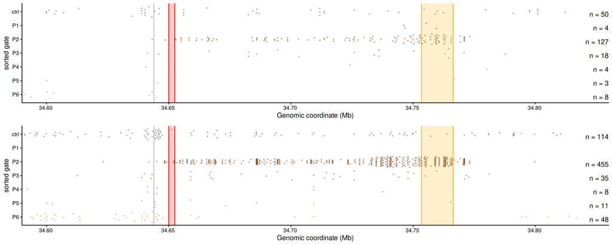

```r
plot_grid(p23_MK02_bs_rep1, p23_MK02_bs_rep2, ncol = 1)
```

### 1xCBS_Sox2P_Fw

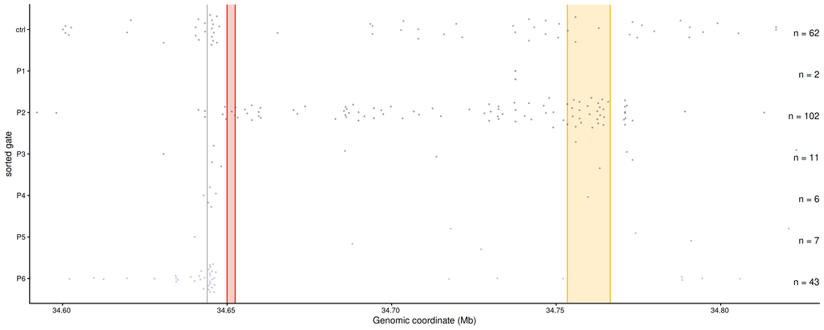

```r
all_exp = unique(tib_filtered_curated_strict$experiment)

#Rep 1
p23_MK03_bs_rep1 =
plot_beeswarm_only(TIB = tib_filtered_curated_strict %>%
                   filter(hopped & chr == "chr3" & replicate == "rep1" & population != "P0") %>% droplevels(),
                   EXP = all_exp,
                   CL = "23_MK03_C1",
                   PLOT_ANNOT = T,
                   PLOT_CTCF = F,
                   P_RANGE = prange_zoom_paper,
                   POINT_SIZE = 1.5)
p23_MK03_bs_rep1
```

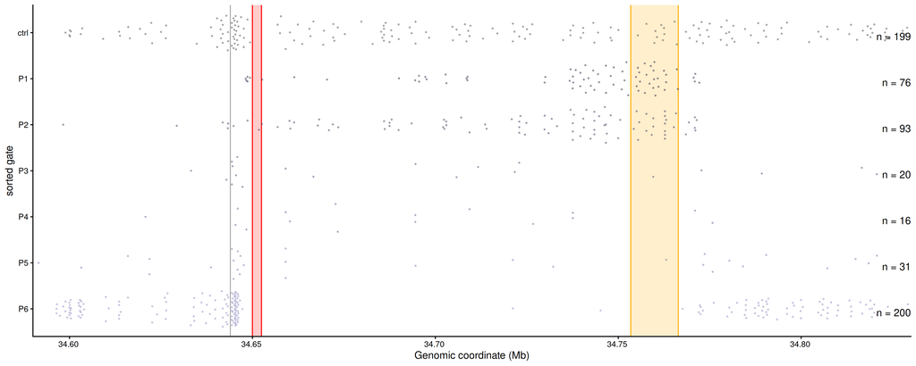

```r
#Rep 2
p23_MK03_bs_rep2 =
plot_beeswarm_only(TIB = tib_filtered_curated_strict %>%
                   filter(hopped & chr == "chr3" & replicate == "rep2" & population != "P0") %>% droplevels(),
                   EXP = all_exp,
                   CL = "23_MK03_C1",
                   PLOT_ANNOT = T,
                   PLOT_CTCF = F,
                   P_RANGE = prange_zoom_paper,
                   POINT_SIZE = 1.5)
p23_MK03_bs_rep2
```

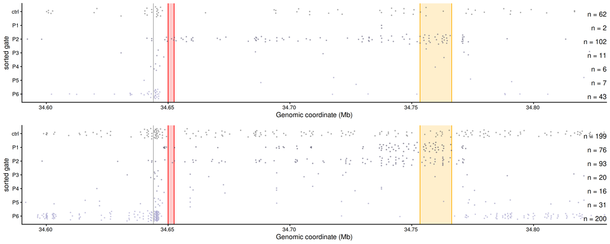

```r
plot_grid(p23_MK03_bs_rep1, p23_MK03_bs_rep2, ncol = 1)
```

## Correlation of replicates

### Sox2P - Figure S1C

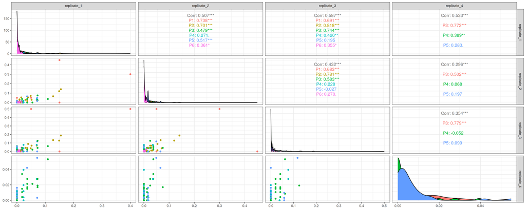

```r
bin_borders = seq(from = prange_zoom_paper[1], to = prange_zoom_paper[2], by = 5000)
bin_borders_tib = tibble(start_window = bin_borders) %>%
  mutate(interval_number = row_number())

#count the number of integrations per cell line, population and bin
N_ints_pop_tib = tib_filtered_curated_strict %>%
  filter(cell_line == "23_34A" & hopped) %>%
  group_by(experiment, population) %>%
  summarize(N_ints_pop = n())

N_ints_bins_tmp = tib_filtered_curated_strict %>%
  filter(chr == "chr3" & cell_line == "23_34A" & hopped) %>%
  mutate(interval_number = findInterval(start, bin_borders)) %>%
  group_by(experiment, population, interval_number) %>%
  summarize(N_ints_bin = n()) %>%
  left_join(N_ints_pop_tib) %>%
  mutate(fract_ints_bin = N_ints_bin/N_ints_pop)

frac_ints_bins_wide = N_ints_bins_tmp %>%
  pivot_wider(id_cols = c(population, interval_number),
              names_from = experiment,
              values_from = fract_ints_bin,
              values_fill = 0)

frac_ints_bins_wide_full =
  #make all combinations of interval_number and population
  expand_grid(interval_number = c(0, bin_borders_tib$interval_number),
              population = unique(N_ints_bins_tmp$population)) %>%
  #add the fractions and replace all NAs with zeros
  left_join(frac_ints_bins_wide) %>%
  mutate(across(everything(), ~replace_na(.x, 0)))

#plot pairs
filter(frac_ints_bins_wide_full,
               population != 'ctrl' &
               !interval_number %in% c(0, max(interval_number))) %>% #remove the outer bins, which are bigger than 5kb
  dplyr::rename(replicate_1 = E2138,
                replicate_2 = E2282,
                replicate_3 = E2285,
                replicate_4 = E2712) %>%
  mutate(replicate_4 = case_when(population %in% c("P1", "P2", "P6") ~ NA, #replicate 4 only contained P3-P5
                                 .default = replicate_4)) %>%
  ggpairs(aes(col = population),
        columns = paste0('replicate_',1:4),
        lower = list(continuous = "points", stroke = NA), #, mapping=aes(color=population
        upper = list(continuous = wrap("cor", method = "spearman"))) +
  theme_bw(base_size = 12)
```

### 3xCBS_Fw_Sox2P - Figure S1E

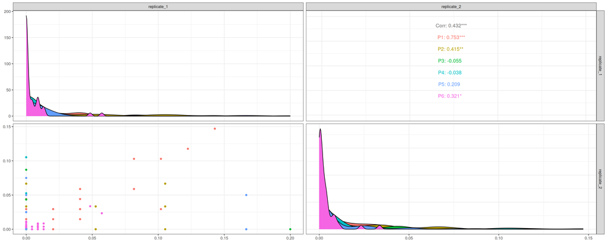

```r
bin_borders = seq(from = prange_zoom_paper[1], to = prange_zoom_paper[2], by = 5000)
bin_borders_tib = tibble(start_window = bin_borders) %>%
  mutate(interval_number = row_number())

#count the number of integrations per cell line, population and bin
N_ints_pop_tib = tib_filtered_curated_strict %>%
  filter(cell_line == "23_MK01_C5" & hopped) %>%
  group_by(experiment, population) %>%
  summarize(N_ints_pop = n())

N_ints_bins_tmp = tib_filtered_curated_strict %>%
  filter(chr == "chr3" & cell_line == "23_MK01_C5" & hopped) %>%
  mutate(interval_number = findInterval(start, bin_borders)) %>%
  group_by(experiment, population, interval_number) %>%
  summarize(N_ints_bin = n()) %>%
  left_join(N_ints_pop_tib) %>%
  mutate(fract_ints_bin = N_ints_bin/N_ints_pop)

frac_ints_bins_wide = N_ints_bins_tmp %>%
  pivot_wider(id_cols = c(population, interval_number),
              names_from = experiment,
              values_from = fract_ints_bin,
              values_fill = 0)

frac_ints_bins_wide_full =
  #make all combinations of interval_number and population
  expand_grid(interval_number = c(0, bin_borders_tib$interval_number),
              population = unique(N_ints_bins_tmp$population)) %>%
  #add the fractions and replace all NAs with zeros
  left_join(frac_ints_bins_wide) %>%
  mutate(across(everything(), ~replace_na(.x, 0)))

#plot pairs
pMK01_rep_cor =
filter(frac_ints_bins_wide_full,
               population != 'ctrl' &
               !interval_number %in% c(0, max(interval_number))) %>% #remove the outer bins, which are bigger than 5kb
  dplyr::rename(replicate_1 = E2285,
                replicate_2 = E2401) %>%
  ggpairs(aes(col = population),
        columns = paste0('replicate_',1:2),
        lower = list(continuous = "points", stroke = NA), #, mapping=aes(color=population
        upper = list(continuous = wrap("cor", method = "spearman"))) +
  theme_bw(base_size = 12)

pMK01_rep_cor
```

### 3xCBS_Rv_Sox2P - Figure S1E

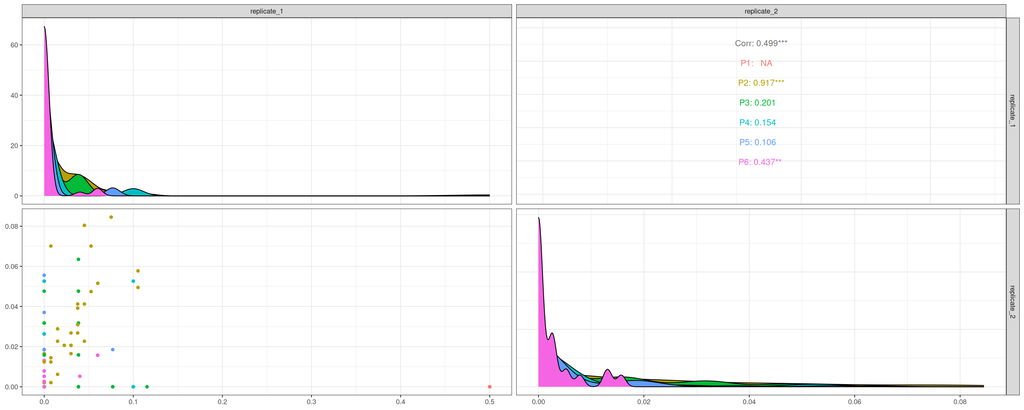

```r
bin_borders = seq(from = prange_zoom_paper[1], to = prange_zoom_paper[2], by = 5000)
bin_borders_tib = tibble(start_window = bin_borders) %>%
  mutate(interval_number = row_number())

#count the number of integrations per cell line, population and bin
N_ints_pop_tib = tib_filtered_curated_strict %>%
  filter(cell_line == "23_MK02_C2" & hopped) %>%
  group_by(experiment, population) %>%
  summarize(N_ints_pop = n())

N_ints_bins_tmp = tib_filtered_curated_strict %>%
  filter(chr == "chr3" & cell_line == "23_MK02_C2" & hopped) %>%
  mutate(interval_number = findInterval(start, bin_borders)) %>%
  group_by(experiment, population, interval_number) %>%
  summarize(N_ints_bin = n()) %>%
  left_join(N_ints_pop_tib) %>%
  mutate(fract_ints_bin = N_ints_bin/N_ints_pop)

frac_ints_bins_wide = N_ints_bins_tmp %>%
  pivot_wider(id_cols = c(population, interval_number),
              names_from = experiment,
              values_from = fract_ints_bin,
              values_fill = 0)

frac_ints_bins_wide_full =
  #make all combinations of interval_number and population
  expand_grid(interval_number = c(0, bin_borders_tib$interval_number),
              population = unique(N_ints_bins_tmp$population)) %>%
  #add the fractions and replace all NAs with zeros
  left_join(frac_ints_bins_wide) %>%
  mutate(across(everything(), ~replace_na(.x, 0)))

#plot pairs
pMK02_rep_cor =
filter(frac_ints_bins_wide_full,
               population != 'ctrl' &
               !interval_number %in% c(0, max(interval_number))) %>% #remove the outer bins, which are bigger than 5kb
  dplyr::rename(replicate_1 = E2285,
                replicate_2 = E2401) %>%
  ggpairs(aes(col = population),
        columns = paste0('replicate_',1:2),
        lower = list(continuous = "points", stroke = NA), #, mapping=aes(color=population
        upper = list(continuous = wrap("cor", method = "spearman"))) +
  theme_bw(base_size = 12)

pMK02_rep_cor
```

### 1xCBS_Fw_Sox2P - Figure S1E

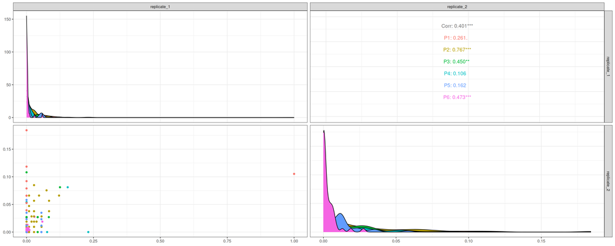

```r
bin_borders = seq(from = prange_zoom_paper[1], to = prange_zoom_paper[2], by = 5000)
bin_borders_tib = tibble(start_window = bin_borders) %>%
  mutate(interval_number = row_number())

#count the number of integrations per cell line, population and bin
N_ints_pop_tib = tib_filtered_curated_strict %>%
  filter(cell_line == "23_MK03_C1" & hopped) %>%
  group_by(experiment, population) %>%
  summarize(N_ints_pop = n())

N_ints_bins_tmp = tib_filtered_curated_strict %>%
  filter(chr == "chr3" & cell_line == "23_MK03_C1" & hopped) %>%
  mutate(interval_number = findInterval(start, bin_borders)) %>%
  group_by(experiment, population, interval_number) %>%
  summarize(N_ints_bin = n()) %>%
  left_join(N_ints_pop_tib) %>%
  mutate(fract_ints_bin = N_ints_bin/N_ints_pop)

frac_ints_bins_wide = N_ints_bins_tmp %>%
  pivot_wider(id_cols = c(population, interval_number),
              names_from = experiment,
              values_from = fract_ints_bin,
              values_fill = 0)

frac_ints_bins_wide_full =
  #make all combinations of interval_number and population
  expand_grid(interval_number = c(0, bin_borders_tib$interval_number),
              population = unique(N_ints_bins_tmp$population)) %>%
  #add the fractions and replace all NAs with zeros
  left_join(frac_ints_bins_wide) %>%
  mutate(across(everything(), ~replace_na(.x, 0)))

#plot pairs
pMK03_rep_cor =
filter(frac_ints_bins_wide_full,
               population != 'ctrl' &
               !interval_number %in% c(0, max(interval_number))) %>% #remove the outer bins, which are bigger than 5kb
  dplyr::rename(replicate_1 = E2285,
                replicate_2 = E2401) %>%
  ggpairs(aes(col = population),
        columns = paste0('replicate_',1:2),
        lower = list(continuous = "points", stroke = NA), #, mapping=aes(color=population
        upper = list(continuous = wrap("cor", method = "spearman"))) +
  theme_bw(base_size = 12)

pMK03_rep_cor
```

# Annotate weak enhancer upstream of SCR

Load ChIP seq tracks of active marks (H3K27Ac, P300) and pluripotency TFs (SOX2, NANOG, OCT4) and plot together with expression score for each construct. ## Load ChIP-seq datasets datasets

```r
# ChIP-seq datasets used can be found in Table S6

paths_ext_data_files_figure = c(
  H3K27ac = '/DATA/usr/c.moene/public_data/ChIP/Histons/H3K27ac_ENCFF583WVZ_signal_pval.bigWig',
  P300_serum = '/DATA/shared/projects/TRIP/TRIP_TF_REPORTERS/annotation/cistrome_v2.0/mm10/bigWig/p300_2821_Creyghton.bw',
  CTCF = '/DATA/projects/Sox2/CTCF_ChIP_analysis/results/bigwig/6764_2_ME_E2_CGATGT_S2_R1_001.bw', #new, aligned to mm10 only
  SOX2 = '/DATA/shared/projects/TRIP/TRIP_TF_REPORTERS/annotation/cistrome_v2.0/mm10/bigWig/SOX2_73602_Chronis.bw',
  OCT4 = '/DATA/shared/projects/TRIP/TRIP_TF_REPORTERS/annotation/cistrome_v2.0/mm10/bigWig/OCT4_73603_Chronis.bw',
  NANOG = '/DATA/shared/projects/TRIP/TRIP_TF_REPORTERS/annotation/cistrome_v2.0/mm10/bigWig/NANOG_73565_Chronis.bw')
```

## Plot expression scores facet by strand

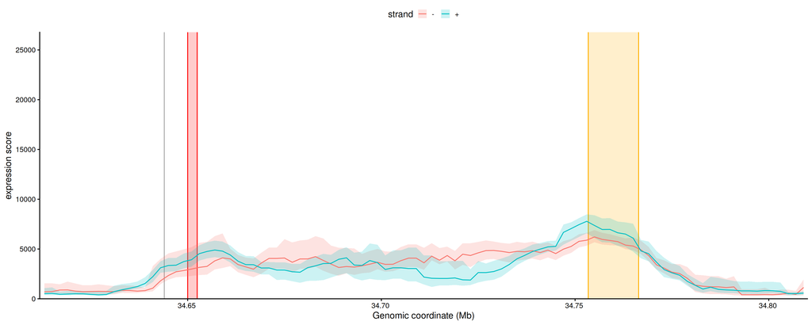

```r
# Sox2P - pME034
pExpr_23_34A_str =
ggplot(expr_score_sum_tib_filt_comb_23_34A_str, aes(x = mid_interval)) +
  # annotate enhancer
  list(
    annotate("rect", xmin = start(enhancer), xmax = end(enhancer), ymin = -Inf, ymax = Inf, alpha = .2, fill = brown),
    geom_vline(xintercept = c(start(enhancer), end(enhancer)), col = brown),
    # annotate gene
    annotate("rect", xmin = start(Sox2_gene), xmax = end(Sox2_gene), ymin = -Inf, ymax = Inf,alpha = .2, fill = 'red'),
    #geom_vline(xintercept = start(CTCF_mm10.chr3_extra), col = 'darkgrey',linetype = 'dotted'),
    geom_vline(xintercept = c(start(Sox2_gene), end(Sox2_gene)), col = 'red'),
    geom_vline(xintercept = start(landingPad_23), col = 'darkgrey')
  ) +

  ## plot the confidence interval based on the resampled data
  geom_ribbon(aes(ymin = expr_score_window_lower_sel, ymax = expr_score_window_upper_sel, fill = strand), alpha = 0.2) +
  #geom_line( aes(y = expr_score_window_mean), col = "orange") +
  ## plot the median based on the resampled data
  geom_line(aes(y = expr_score_window_median_sel, col = strand)) +

  #axes
  scale_x_continuous(breaks = scales::pretty_breaks(n = 3), labels = scales::unit_format(scale = 1E-6, accuracy = 0.01, unit=NULL),
                     limits=prange_ChIP, expand=c(0,0)) +
  scale_y_continuous(expand=expansion(mult = c(0, 0.05)),
                     breaks = scales::pretty_breaks(n=6),
                     limits = c(0, 25500)) +
  labs(x='Genomic coordinate (Mb)',y='expression score') +
  theme_classic(base_size = 16) +
  theme(legend.position = 'top')

pExpr_23_34A_str
```

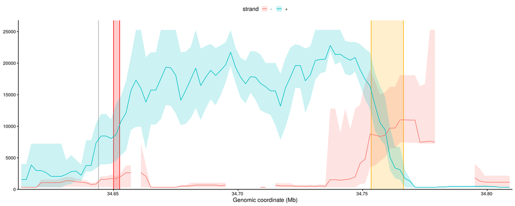

```r
#3xCBS_Fw_Sox2P - MK01
pExpr_23_MK01_C5_str =
ggplot(expr_score_sum_tib_filt_comb_23_MK01_C5_str, aes(x = mid_interval)) +
  # annotate enhancer
  list(
    annotate("rect", xmin = start(enhancer), xmax = end(enhancer), ymin = -Inf, ymax = Inf, alpha = .2, fill = brown),
    geom_vline(xintercept = c(start(enhancer), end(enhancer)), col = brown),
    # annotate gene
    annotate("rect", xmin = start(Sox2_gene), xmax = end(Sox2_gene), ymin = -Inf, ymax = Inf,alpha = .2, fill = 'red'),
    geom_vline(xintercept = c(start(Sox2_gene), end(Sox2_gene)), col = 'red'),
    #geom_vline(xintercept = start(CTCF_mm10.chr3_extra), col = 'darkgrey',linetype = 'dotted'),
    #geom_vline(xintercept = start(landingPad_8), col = 'darkgrey'),
    geom_vline(xintercept = start(landingPad_23), col = 'darkgrey')
  ) +

  ## plot the confidence interval based on the resampled data
  geom_ribbon(aes(ymin = expr_score_window_lower_sel, ymax = expr_score_window_upper_sel, fill = strand), alpha = 0.2) +
  #geom_line( aes(y = expr_score_window_mean), col = 'orange') +
  ## plot the median based on the resampled data
  geom_line(aes(y = expr_score_window_median_sel, col = strand)) +

  #axes
  scale_x_continuous(breaks = scales::pretty_breaks(n = 3), labels = scales::unit_format(scale = 1E-6, accuracy = 0.01, unit=NULL),
                     limits=prange_ChIP, expand=c(0,0)) +
  scale_y_continuous(expand=expansion(mult = c(0, 0.05)),
                     breaks = scales::pretty_breaks(n=6),
                     limits = c(0, 25500)) +
  labs(x='Genomic coordinate (Mb)',y='expression score') +
  theme_classic(base_size = 16) +
  theme(legend.position = 'top') +
  theme(axis.title.y=element_blank())

pExpr_23_MK01_C5_str
```

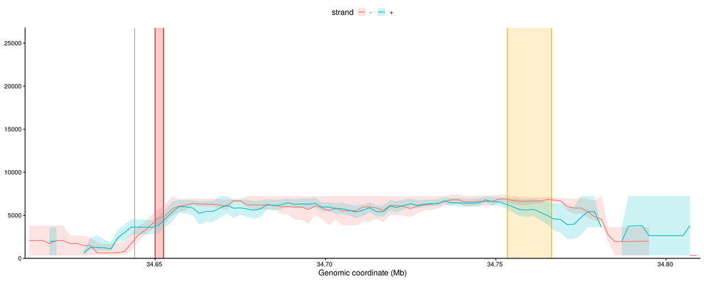

```r
#3xCBS_Rv_Sox2P - MK02
pExpr_23_MK02_C2_str =
ggplot(expr_score_sum_tib_filt_comb_23_MK02_C2_str, aes(x = mid_interval)) +
  # annotate enhancer
  list(
    annotate("rect", xmin = start(enhancer), xmax = end(enhancer), ymin = -Inf, ymax = Inf, alpha = .2, fill = brown),
    geom_vline(xintercept = c(start(enhancer), end(enhancer)), col = brown),
    # annotate gene
    annotate("rect", xmin = start(Sox2_gene), xmax = end(Sox2_gene), ymin = -Inf, ymax = Inf,alpha = .2, fill = 'red'),
    #geom_vline(xintercept = start(CTCF_mm10.chr3_extra), col = 'darkgrey',linetype = 'dotted'),
    geom_vline(xintercept = c(start(Sox2_gene), end(Sox2_gene)), col = 'red'),
    geom_vline(xintercept = start(landingPad_23), col = 'darkgrey')
  ) +

  ## plot the confidence interval based on the resampled data
  geom_ribbon(aes(ymin = expr_score_window_lower_sel, ymax = expr_score_window_upper_sel, fill = strand), alpha = 0.2) +
  #geom_line( aes(y = expr_score_window_mean), col = 'orange') +
  ## plot the median based on the resampled data
  geom_line(aes(y = expr_score_window_median_sel, col = strand)) +

  #axes
  scale_x_continuous(breaks = scales::pretty_breaks(n = 3), labels = scales::unit_format(scale = 1E-6, accuracy = 0.01, unit=NULL),
                     limits=prange_ChIP, expand=c(0,0)) +
  scale_y_continuous(expand=expansion(mult = c(0, 0.05)),
                     breaks = scales::pretty_breaks(n=6),
                     limits = c(0, 25500)) +
  labs(x='Genomic coordinate (Mb)',y='expression score') +
  theme_classic(base_size = 16) +
  theme(legend.position = 'top') +
  theme(axis.title.y=element_blank())

pExpr_23_MK02_C2_str
```

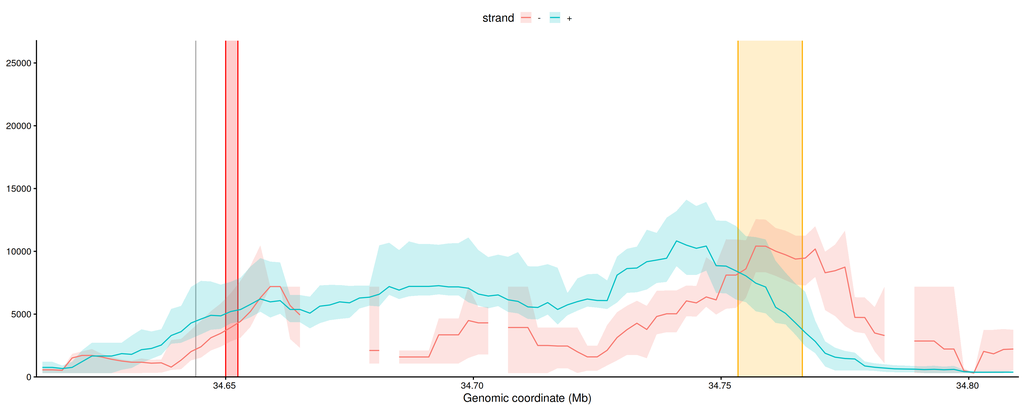

```r
#1xCBS_Fw_Sox2P - MK03
pExpr_23_MK03_C1_str =
ggplot(expr_score_sum_tib_filt_comb_23_MK03_C1_str, aes(x = mid_interval)) +
  # annotate enhancer
  list(
    annotate("rect", xmin = start(enhancer), xmax = end(enhancer), ymin = -Inf, ymax = Inf, alpha = .2, fill = brown),
    geom_vline(xintercept = c(start(enhancer), end(enhancer)), col = brown),
    # annotate gene
    annotate("rect", xmin = start(Sox2_gene), xmax = end(Sox2_gene), ymin = -Inf, ymax = Inf,alpha = .2, fill = 'red'),
    #geom_vline(xintercept = start(CTCF_mm10.chr3_extra), col = 'darkgrey',linetype = 'dotted'),
    geom_vline(xintercept = c(start(Sox2_gene), end(Sox2_gene)), col = 'red'),
    geom_vline(xintercept = start(landingPad_23), col = 'darkgrey')
  ) +

  ## plot the confidence interval based on the resampled data
  geom_ribbon(aes(ymin = expr_score_window_lower_sel, ymax = expr_score_window_upper_sel, fill = strand), alpha = 0.2) +
  #geom_line( aes(y = expr_score_window_mean), col = 'orange') +
  ## plot the median based on the resampled data
  geom_line(aes(y = expr_score_window_median_sel, col = strand)) +

  #axes
  scale_x_continuous(breaks = scales::pretty_breaks(n = 3), labels = scales::unit_format(scale = 1E-6, accuracy = 0.01, unit=NULL),
                     limits=prange_ChIP, expand=c(0,0)) +
  scale_y_continuous(expand=expansion(mult = c(0, 0.05)),
                     breaks = scales::pretty_breaks(n=6),
                     limits = c(0, 25500)) +
  labs(x='Genomic coordinate (Mb)',y='expression score') +
  theme_classic(base_size = 16) +
  theme(legend.position = 'top') +
  theme(axis.title.y=element_blank())

pExpr_23_MK03_C1_str
```

## Figure S2F-I, Plot dataset

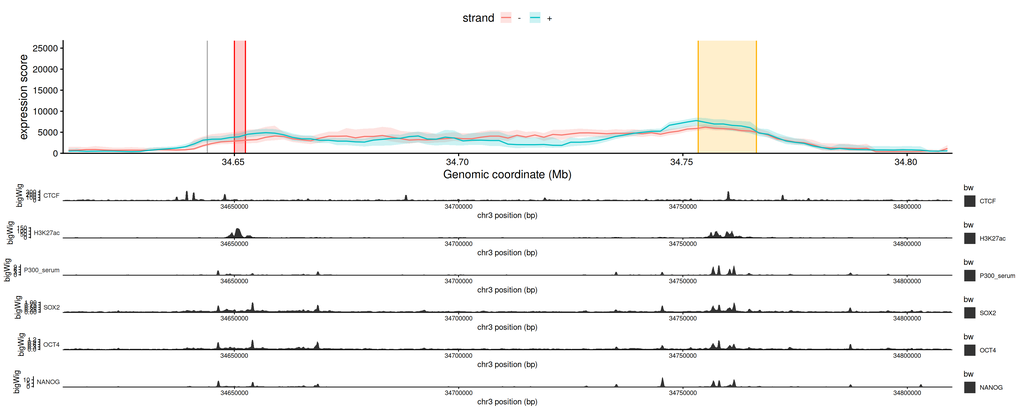

```r
library(Signac)

prange_ChIP_paper_gr = GRanges(seqnames = "chr3", IRanges(start = prange_ChIP[1], end = prange_ChIP[2]))

# Plot for figure
ext_data_files_ls_figure = split(unname(paths_ext_data_files_figure), names(paths_ext_data_files_figure))

#Plot for pME034
cowplot::plot_grid(plotlist = c(list(pExpr_23_34A_str,
                                     BigwigTrack(prange_ChIP_paper_gr, ext_data_files_ls_figure[1], smooth = 500) +
                                       scale_x_continuous(breaks = scales::pretty_breaks(n = 3), expand= c(0,0)),
                                     BigwigTrack(prange_ChIP_paper_gr, ext_data_files_ls_figure[2], smooth = 500) +
                                       scale_x_continuous(breaks = scales::pretty_breaks(n = 3), expand= c(0,0)),
                                     BigwigTrack(prange_ChIP_paper_gr, ext_data_files_ls_figure[5], smooth = 500) +
                                       scale_x_continuous(breaks = scales::pretty_breaks(n = 3), expand= c(0,0)),
                                     BigwigTrack(prange_ChIP_paper_gr, ext_data_files_ls_figure[6], smooth = 500) +
                                       scale_x_continuous(breaks = scales::pretty_breaks(n = 3), expand= c(0,0)),
                                     BigwigTrack(prange_ChIP_paper_gr, ext_data_files_ls_figure[4], smooth = 500) +
                                       scale_x_continuous(breaks = scales::pretty_breaks(n = 3), expand= c(0,0)),
                                     BigwigTrack(prange_ChIP_paper_gr, ext_data_files_ls_figure[3], smooth = 500) +
                                       scale_x_continuous(breaks = scales::pretty_breaks(n = 3), expand= c(0,0)))),
                   ncol = 1, align="v", axis="lr", rel_heights = c(1.5, 0.3, 0.3, 0.3, 0.3, 0.3, 0.3))
```

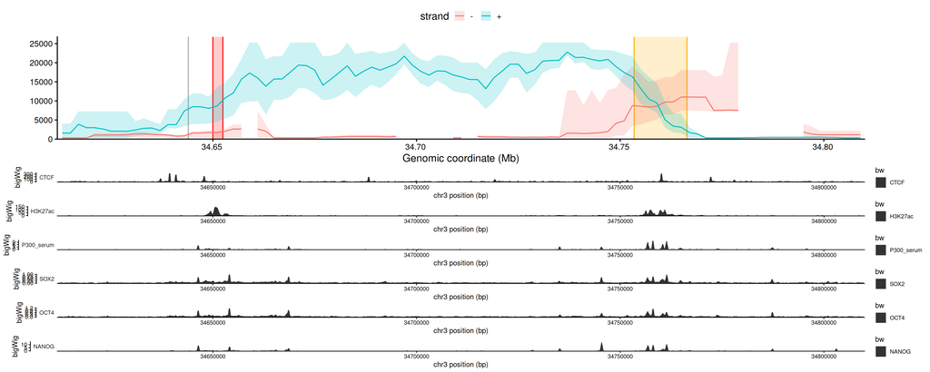

```r
#Plot for MK01
cowplot::plot_grid(plotlist = c(list(pExpr_23_MK01_C5_str,
                                     BigwigTrack(prange_ChIP_paper_gr, ext_data_files_ls_figure[1], smooth = 500) +
                                       scale_x_continuous(breaks = scales::pretty_breaks(n = 3), expand= c(0,0)),
                                     BigwigTrack(prange_ChIP_paper_gr, ext_data_files_ls_figure[2], smooth = 500) +
                                       scale_x_continuous(breaks = scales::pretty_breaks(n = 3), expand= c(0,0)),
                                     BigwigTrack(prange_ChIP_paper_gr, ext_data_files_ls_figure[5], smooth = 500) +
                                       scale_x_continuous(breaks = scales::pretty_breaks(n = 3), expand= c(0,0)),
                                     BigwigTrack(prange_ChIP_paper_gr, ext_data_files_ls_figure[6], smooth = 500) +
                                       scale_x_continuous(breaks = scales::pretty_breaks(n = 3), expand= c(0,0)),
                                     BigwigTrack(prange_ChIP_paper_gr, ext_data_files_ls_figure[4], smooth = 500) +
                                       scale_x_continuous(breaks = scales::pretty_breaks(n = 3), expand= c(0,0)),
                                     BigwigTrack(prange_ChIP_paper_gr, ext_data_files_ls_figure[3], smooth = 500) +
                                       scale_x_continuous(breaks = scales::pretty_breaks(n = 3), expand= c(0,0)))),
                   ncol = 1, align="v", axis="lr", rel_heights = c(1.5, 0.3, 0.3, 0.3, 0.3, 0.3, 0.3))
```

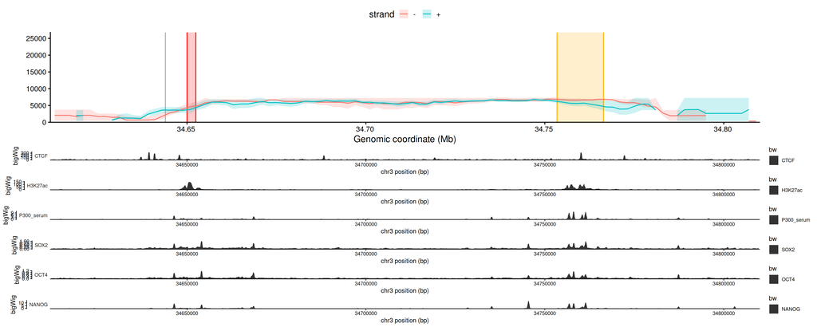

```r
#Plot for MK02
cowplot::plot_grid(plotlist = c(list(pExpr_23_MK02_C2_str,
                                     BigwigTrack(prange_ChIP_paper_gr, ext_data_files_ls_figure[1], smooth = 500) +
                                       scale_x_continuous(breaks = scales::pretty_breaks(n = 3), expand= c(0,0)),
                                     BigwigTrack(prange_ChIP_paper_gr, ext_data_files_ls_figure[2], smooth = 500) +
                                       scale_x_continuous(breaks = scales::pretty_breaks(n = 3), expand= c(0,0)),
                                     BigwigTrack(prange_ChIP_paper_gr, ext_data_files_ls_figure[5], smooth = 500) +
                                       scale_x_continuous(breaks = scales::pretty_breaks(n = 3), expand= c(0,0)),
                                     BigwigTrack(prange_ChIP_paper_gr, ext_data_files_ls_figure[6], smooth = 500) +
                                       scale_x_continuous(breaks = scales::pretty_breaks(n = 3), expand= c(0,0)),
                                     BigwigTrack(prange_ChIP_paper_gr, ext_data_files_ls_figure[4], smooth = 500) +
                                       scale_x_continuous(breaks = scales::pretty_breaks(n = 3), expand= c(0,0)),
                                     BigwigTrack(prange_ChIP_paper_gr, ext_data_files_ls_figure[3], smooth = 500) +
                                       scale_x_continuous(breaks = scales::pretty_breaks(n = 3), expand= c(0,0)))),
                   ncol = 1, align="v", axis="lr", rel_heights = c(1.5, 0.3, 0.3, 0.3, 0.3, 0.3, 0.3))
```

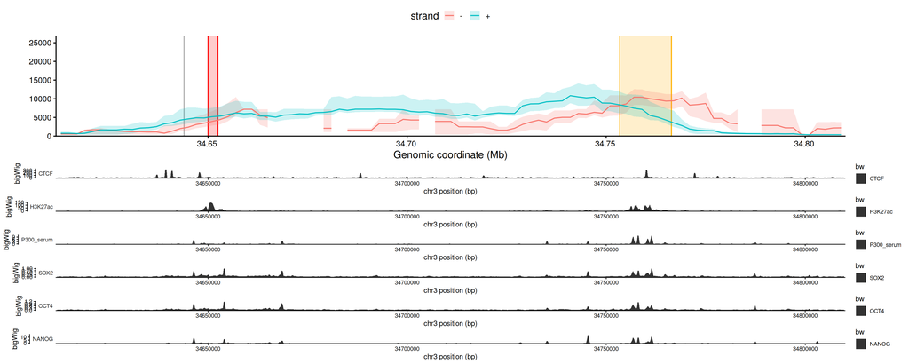

```r
#Plot for MK03
cowplot::plot_grid(plotlist = c(list(pExpr_23_MK03_C1_str,
                                     BigwigTrack(prange_ChIP_paper_gr, ext_data_files_ls_figure[1], smooth = 500) +
                                       scale_x_continuous(breaks = scales::pretty_breaks(n = 3), expand= c(0,0)),
                                     BigwigTrack(prange_ChIP_paper_gr, ext_data_files_ls_figure[2], smooth = 500) +
                                       scale_x_continuous(breaks = scales::pretty_breaks(n = 3), expand= c(0,0)),
                                     BigwigTrack(prange_ChIP_paper_gr, ext_data_files_ls_figure[5], smooth = 500) +
                                       scale_x_continuous(breaks = scales::pretty_breaks(n = 3), expand= c(0,0)),
                                     BigwigTrack(prange_ChIP_paper_gr, ext_data_files_ls_figure[6], smooth = 500) +
                                       scale_x_continuous(breaks = scales::pretty_breaks(n = 3), expand= c(0,0)),
                                     BigwigTrack(prange_ChIP_paper_gr, ext_data_files_ls_figure[4], smooth = 500) +
                                       scale_x_continuous(breaks = scales::pretty_breaks(n = 3), expand= c(0,0)),
                                     BigwigTrack(prange_ChIP_paper_gr, ext_data_files_ls_figure[3], smooth = 500) +
                                       scale_x_continuous(breaks = scales::pretty_breaks(n = 3), expand= c(0,0)))),
                   ncol = 1, align="v", axis="lr", rel_heights = c(1.5, 0.3, 0.3, 0.3, 0.3, 0.3, 0.3))
```

# Extract highest numbers of MK03

```r
# -------------------------------------------------------------------------
# Identify 1xCBS_Fw_Sox2P (+ strand) expression peak upstream of SCR
# -------------------------------------------------------------------------

SCR_start <- start(enhancer)

MK03_plus_upstream <- expr_score_sum_tib_filt_comb_23_MK03_C1_str %>%
  filter(
    strand == "+",
    mid_interval < SCR_start,
    !is.na(expr_score_window_median_sel)
  ) %>%
  mutate(
    distance_upstream_SCR_kb =
      (SCR_start - mid_interval) / 1000
  ) %>%
  select(
    mid_interval,
    distance_upstream_SCR_kb,
    expr_score_window_median_sel,
    expr_score_window_lower_sel,
    expr_score_window_upper_sel,
    total_ints_window
  ) %>%
  arrange(desc(expr_score_window_median_sel))

MK03_plus_upstream
```

```
## # A tibble: 100 × 8
## # Groups:   strand, interval_number [100]
##    strand interval_number mid_interval distance_upstream_SCR_kb
##    <chr>            <int>        <dbl>                    <dbl>
##  1 +                  121     34741000                    12.4
##  2 +                  122     34743000                    10.4
##  3 +                  124     34747000                     6.42
##  4 +                  123     34745000                     8.41
##  5 +                  120     34739000                    14.4
##  6 +                  119     34737000                    16.4
##  7 +                  118     34735000                    18.4
##  8 +                  125     34749000                     4.42
##  9 +                  126     34751000                     2.42
## 10 +                  117     34733000                    20.4
## # ℹ 90 more rows
## # ℹ 4 more variables: expr_score_window_median_sel <dbl>,
## #   expr_score_window_lower_sel <dbl>, expr_score_window_upper_sel <dbl>,
## #   total_ints_window <dbl>
```

```r
# Highest expression window
MK03_plus_upstream %>%
  slice_max(
    expr_score_window_median_sel,
    n = 1,
    with_ties = FALSE
  )
```

```
## # A tibble: 100 × 8
## # Groups:   strand, interval_number [100]
##    strand interval_number mid_interval distance_upstream_SCR_kb
##    <chr>            <int>        <dbl>                    <dbl>
##  1 +                   28     34555000                     198.
##  2 +                   29     34557000                     196.
##  3 +                   30     34559000                     194.
##  4 +                   31     34561000                     192.
##  5 +                   32     34563000                     190.
##  6 +                   33     34565000                     188.
##  7 +                   34     34567000                     186.
##  8 +                   35     34569000                     184.
##  9 +                   36     34571000                     182.
## 10 +                   37     34573000                     180.
## # ℹ 90 more rows
## # ℹ 4 more variables: expr_score_window_median_sel <dbl>,
## #   expr_score_window_lower_sel <dbl>, expr_score_window_upper_sel <dbl>,
## #   total_ints_window <dbl>
```

```r
MK03_plus_upstream %>%
  filter(
    distance_upstream_SCR_kb >= 8,
    distance_upstream_SCR_kb <= 18
  ) %>%
  arrange(desc(expr_score_window_median_sel))
```

```
## # A tibble: 5 × 8
## # Groups:   strand, interval_number [5]
##   strand interval_number mid_interval distance_upstream_SCR_kb
##   <chr>            <int>        <dbl>                    <dbl>
## 1 +                  121     34741000                    12.4
## 2 +                  122     34743000                    10.4
## 3 +                  123     34745000                     8.41
## 4 +                  120     34739000                    14.4
## 5 +                  119     34737000                    16.4
## # ℹ 4 more variables: expr_score_window_median_sel <dbl>,
## #   expr_score_window_lower_sel <dbl>, expr_score_window_upper_sel <dbl>,
## #   total_ints_window <dbl>
```

```r
MK03_plus_upstream %>%
  mutate(
    region = if_else(
      distance_upstream_SCR_kb >= 8 &
      distance_upstream_SCR_kb <= 18,
      "8-18 kb upstream",
      "other upstream"
    )
  ) %>%
  group_by(region) %>%
  summarise(
    max_expression = max(
      expr_score_window_median_sel,
      na.rm = TRUE
    ),
    median_expression = median(
      expr_score_window_median_sel,
      na.rm = TRUE
    ),
    .groups = "drop"
  )
```

```
## # A tibble: 2 × 3
##   region           max_expression median_expression
##   <chr>                     <dbl>             <dbl>
## 1 8-18 kb upstream         10830.            10242.
## 2 other upstream           10421.             4905.
```

**Conclusion:** There is a high local maximum in the + strand immediatly upstream of the SCR, with the highest expression score window centerd ~ 12 kb upstream. Remember that we use a sliding window approach, therefore we cannot simply state coordinates.

#GEnerate the ultimate plot Here i want to look at the local maxima of the peak, overlap the expression score with the DHSs from Maurano and the ChIP-seq tracks.

## 1. Prepare peak, DHS annotation and plotting range

```r
# =============================================================================
# Prepare expression-score peak and Brosh/Ribeiro DHS annotations
# =============================================================================

# Focused region around DHS19/20 and the SCR
prange_DHS_peak <- c(
  34.72E6,
  34.78E6
)

prange_DHS_peak_gr <- GRanges(
  seqnames = "chr3",
  ranges = IRanges(
    start = prange_DHS_peak[1],
    end = prange_DHS_peak[2]
  )
)


# -----------------------------------------------------------------------------
# Prepare Ribeiro / Brosh DHS annotations
# -----------------------------------------------------------------------------

Ribeiro_DHS_mm10 <- Ribeiro_Brosh_DHS_annotations %>%
  mutate(
    # Ribeiro coordinates are BED-style:
    # convert 0-based start to 1-based genomic coordinate
    start = chromStart + 1,
    end   = chromEnd,
    label = str_remove(name, "^Sox2")
  ) %>%
  filter(
    str_detect(name, "^Sox2(DHS|CTCF)")
  )


# DHSs / CTCF sites in plotting region
Ribeiro_DHS_plot <- Ribeiro_DHS_mm10 %>%
  filter(
    end >= prange_DHS_peak[1],
    start <= prange_DHS_peak[2]
  )


# Specifically DHS19 and DHS20
Ribeiro_DHS19_20 <- Ribeiro_DHS_plot %>%
  filter(
    name %in% c(
      "Sox2DHS19",
      "Sox2DHS20"
    )
  )


# -----------------------------------------------------------------------------
# Identify highest expression-score bin for 1xCBS_Fw_Sox2P, + strand
# -----------------------------------------------------------------------------

MK03_plus_peak <- expr_score_sum_per_cl_str %>%
  filter(
    cell_line == "23_MK03_C1",
    strand == "+",
    mid_interval < start(enhancer),
    !is.na(expr_score_window_median_sel)
  ) %>%
  slice_max(
    expr_score_window_median_sel,
    n = 1,
    with_ties = FALSE
  )


# Determine spacing of expression-score bins
expr_bin_size <- expr_score_sum_per_cl_str %>%
  filter(
    cell_line == "23_MK03_C1",
    strand == "+"
  ) %>%
  pull(mid_interval) %>%
  unique() %>%
  sort() %>%
  diff() %>%
  median()


# Genomic interval corresponding to the bin centred on the maximum
peak_bin <- MK03_plus_peak %>%
  transmute(
    xmin = mid_interval - expr_bin_size / 2,
    xmax = mid_interval + expr_bin_size / 2,
    peak_center = mid_interval,
    expression_score = expr_score_window_median_sel,
    distance_upstream_SCR_kb =
      (start(enhancer) - mid_interval) / 1000
  )


# Inspect
peak_bin
```

```
## # A tibble: 100 × 7
## # Groups:   strand, interval_number [100]
##    strand interval_number     xmin     xmax peak_center expression_score
##    <chr>            <int>    <dbl>    <dbl>       <dbl>            <dbl>
##  1 +                   28 34554000 34556000    34555000             310.
##  2 +                   29 34556000 34558000    34557000             310.
##  3 +                   30 34558000 34560000    34559000             310.
##  4 +                   31 34560000 34562000    34561000            1114.
##  5 +                   32 34562000 34564000    34563000             966.
##  6 +                   33 34564000 34566000    34565000             966.
##  7 +                   34 34566000 34568000    34567000            1099.
##  8 +                   35 34568000 34570000    34569000             953.
##  9 +                   36 34570000 34572000    34571000             953.
## 10 +                   37 34572000 34574000    34573000             953.
## # ℹ 90 more rows
## # ℹ 1 more variable: distance_upstream_SCR_kb <dbl>
```

```r
Ribeiro_DHS19_20
```

```
## # A tibble: 2 × 8
##   chrom chromStart chromEnd name      Reference    start      end label
##   <chr>      <dbl>    <dbl> <chr>     <chr>        <dbl>    <dbl> <chr>
## 1 chr3    34734858 34735271 Sox2DHS19 mm10      34734859 34735271 DHS19
## 2 chr3    34744267 34746101 Sox2DHS20 mm10      34744268 34746101 DHS20
```

## 2. + strand expression score panel

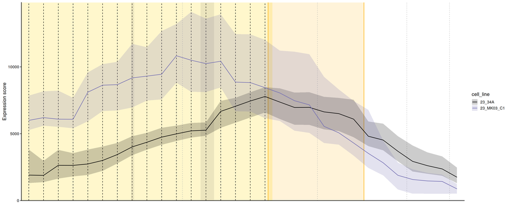

```r
# =============================================================================
# Expression-score panel: + strand
# =============================================================================

p_expr_peak <- expr_score_sum_per_cl_str %>%

  filter(
    cell_line %in% c(
      "23_34A",       # Sox2P
      "23_MK03_C1"    # 1xCBS_Fw_Sox2P
    ),
    strand == "+"
  ) %>%

  ggplot(
    aes(x = mid_interval)
  ) +


  # ---------------------------------------------------------------------------
  # Highest 1xCBS_Fw expression-score bin
  # ---------------------------------------------------------------------------

  annotate(
    "rect",
    xmin = peak_bin$xmin,
    xmax = peak_bin$xmax,
    ymin = -Inf,
    ymax = Inf,
    fill = "gold",
    alpha = 0.20
  ) +

  geom_vline(
    xintercept = peak_bin$peak_center,
    linetype = "dashed",
    linewidth = 0.5
  ) +



  # ---------------------------------------------------------------------------
  # DHS19 and DHS20
  # ---------------------------------------------------------------------------

  geom_rect(
    data = Ribeiro_DHS19_20,
    aes(
      xmin = start,
      xmax = end
    ),
    ymin = -Inf,
    ymax = Inf,
    inherit.aes = FALSE,
    fill = "grey30",
    alpha = 0.10
  ) +


  # ---------------------------------------------------------------------------
  # SCR
  # ---------------------------------------------------------------------------

  annotate(
    "rect",
    xmin = start(enhancer),
    xmax = end(enhancer),
    ymin = -Inf,
    ymax = Inf,
    alpha = 0.15,
    fill = brown
  ) +

  geom_vline(
    xintercept = c(
      start(enhancer),
      end(enhancer)
    ),
    colour = brown
  ) +


  # ---------------------------------------------------------------------------
  # Endogenous CTCF sites
  # ---------------------------------------------------------------------------

  geom_vline(
    xintercept = start(CTCF_mm10.chr3_extra),
    colour = "darkgrey",
    linetype = "dotted"
  ) +


  # ---------------------------------------------------------------------------
  # Confidence interval
  # ---------------------------------------------------------------------------

  geom_ribbon(
    aes(
      ymin = expr_score_window_lower_sel,
      ymax = expr_score_window_upper_sel,
      fill = cell_line
    ),
    alpha = 0.20
  ) +


  # ---------------------------------------------------------------------------
  # Median expression score
  # ---------------------------------------------------------------------------

  geom_line(
    aes(
      y = expr_score_window_median_sel,
      colour = cell_line
    ),
    linewidth = 0.7
  ) +


  # ---------------------------------------------------------------------------
  # Axes
  # ---------------------------------------------------------------------------

  scale_x_continuous(
    breaks = scales::pretty_breaks(n = 4),
    labels = scales::unit_format(
      scale = 1E-6,
      accuracy = 0.01,
      unit = NULL
    ),
    limits = prange_DHS_peak,
    expand = c(0, 0)
  ) +

  scale_y_continuous(
    expand = expansion(
      mult = c(0, 0.05)
    ),
    breaks = scales::pretty_breaks(n = 5),
    limits = c(0, NA)
  ) +

  labs(
    x = NULL,
    y = "Expression score"
  ) +

  theme_classic(
    base_size = 14
  ) +

  theme(
    legend.position = "right",
    axis.text.x = element_blank(),
    axis.ticks.x = element_blank()
  ) +

  col_scale_MK_CL


p_expr_peak
```

## 3. Dedicated Brosh/Ribeiro DHS annotation track

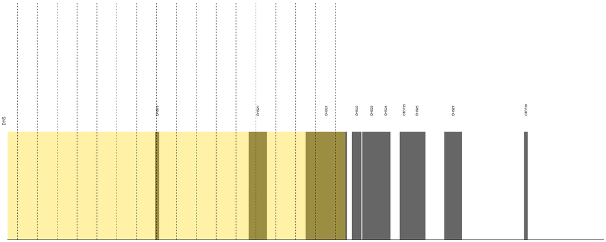

```r
# =============================================================================
# Brosh / Ribeiro DHS annotation track
# =============================================================================

p_DHS <- ggplot(
  Ribeiro_DHS_plot
) +

  geom_rect(
    aes(
      xmin = start,
      xmax = end,
      ymin = 0,
      ymax = 1
    ),
    fill = "grey40"
  ) +

  geom_text(
    aes(
      x = (start + end) / 2,
      y = 1.15,
      label = label
    ),
    angle = 90,
    hjust = 0,
    vjust = 0.5,
    size = 2.6
  ) +

  # Peak-expression bin
  annotate(
    "rect",
    xmin = peak_bin$xmin,
    xmax = peak_bin$xmax,
    ymin = 0,
    ymax = 1,
    fill = "gold",
    alpha = 0.35
  ) +

  geom_vline(
    xintercept = peak_bin$peak_center,
    linetype = "dashed",
    linewidth = 0.4
  ) +

  scale_x_continuous(
    limits = prange_DHS_peak,
    expand = c(0, 0)
  ) +

  scale_y_continuous(
    limits = c(0, 2.2),
    expand = c(0, 0)
  ) +

  labs(
    x = NULL,
    y = "DHS"
  ) +

  theme_classic(
    base_size = 11
  ) +

  theme(
    axis.text = element_blank(),
    axis.ticks = element_blank(),
    axis.line.y = element_blank(),
    axis.title.x = element_blank(),
    axis.title.y = element_text(
      size = 10
    )
  )


p_DHS
```

## 4. Generate the ChIP seq tracks

```r
# P300_serum
# SOX2
# NANOG
# OCT4
# H3K27ac
# CTCF
```

```r
# =============================================================================
# ChIP-seq tracks
# =============================================================================

library(Signac)
library(cowplot)


# -----------------------------------------------------------------------------
# Prepare list of BigWig files
# -----------------------------------------------------------------------------

ext_data_files_ls_figure <- split(
  unname(paths_ext_data_files_figure),
  names(paths_ext_data_files_figure)
)


# Check names before continuing
names(ext_data_files_ls_figure)
```

```
## [1] "CTCF"       "H3K27ac"    "NANOG"      "OCT4"       "P300_serum"
## [6] "SOX2"
```

```r
# -----------------------------------------------------------------------------
# Function to add common annotations to each ChIP-seq track
# -----------------------------------------------------------------------------

add_genomic_annotations <- function(
    p,
    y_label,
    show_x_axis = FALSE
) {

  p +

    # Highlight highest expression-score bin
    annotate(
      "rect",
      xmin = peak_bin$xmin,
      xmax = peak_bin$xmax,
      ymin = -Inf,
      ymax = Inf,
      fill = "gold",
      alpha = 0.18
    ) +

    # DHS19 + DHS20
    geom_rect(
      data = Ribeiro_DHS19_20,
      aes(
        xmin = start,
        xmax = end
      ),
      ymin = -Inf,
      ymax = Inf,
      inherit.aes = FALSE,
      fill = "grey30",
      alpha = 0.10
    ) +

    # Center of highest expression-score bin
    geom_vline(
      xintercept = peak_bin$peak_center,
      linetype = "dashed",
      linewidth = 0.35
    ) +

    scale_x_continuous(
      breaks = scales::pretty_breaks(n = 4),
      labels = scales::unit_format(
        scale = 1E-6,
        accuracy = 0.01,
        unit = NULL
      ),
      limits = prange_DHS_peak,
      expand = c(0, 0)
    ) +

    labs(
      x = if (show_x_axis) {
        "Genomic coordinate (Mb)"
      } else {
        NULL
      },
      y = y_label
    ) +

    theme_classic(
      base_size = 11
    ) +

    theme(
      axis.title.y = element_text(
        size = 10
      ),

      axis.text.x = if (show_x_axis) {
        element_text()
      } else {
        element_blank()
      },

      axis.ticks.x = if (show_x_axis) {
        element_line()
      } else {
        element_blank()
      }
    )
}


# -----------------------------------------------------------------------------
# p300
# -----------------------------------------------------------------------------

p_p300 <- Signac::BigwigTrack(
  region = prange_DHS_peak_gr,
  bigwig = ext_data_files_ls_figure[["P300_serum"]],
  smooth = 100
)

p_p300 <- add_genomic_annotations(
  p_p300,
  y_label = "p300"
)


# -----------------------------------------------------------------------------
# SOX2
# -----------------------------------------------------------------------------

p_SOX2 <- Signac::BigwigTrack(
  region = prange_DHS_peak_gr,
  bigwig = ext_data_files_ls_figure[["SOX2"]],
  smooth = 100
)

p_SOX2 <- add_genomic_annotations(
  p_SOX2,
  y_label = "SOX2"
)


# -----------------------------------------------------------------------------
# NANOG
# -----------------------------------------------------------------------------

p_NANOG <- Signac::BigwigTrack(
  region = prange_DHS_peak_gr,
  bigwig = ext_data_files_ls_figure[["NANOG"]],
  smooth = 100
)

p_NANOG <- add_genomic_annotations(
  p_NANOG,
  y_label = "NANOG"
)


# -----------------------------------------------------------------------------
# OCT4
# -----------------------------------------------------------------------------

p_OCT4 <- Signac::BigwigTrack(
  region = prange_DHS_peak_gr,
  bigwig = ext_data_files_ls_figure[["OCT4"]],
  smooth = 100
)

p_OCT4 <- add_genomic_annotations(
  p_OCT4,
  y_label = "OCT4"
)


# -----------------------------------------------------------------------------
# H3K27ac
# -----------------------------------------------------------------------------

p_H3K27ac <- Signac::BigwigTrack(
  region = prange_DHS_peak_gr,
  bigwig = ext_data_files_ls_figure[["H3K27ac"]],
  smooth = 100
)

p_H3K27ac <- add_genomic_annotations(
  p_H3K27ac,
  y_label = "H3K27ac"
)


# -----------------------------------------------------------------------------
# CTCF
# -----------------------------------------------------------------------------

p_CTCF <- Signac::BigwigTrack(
  region = prange_DHS_peak_gr,
  bigwig = ext_data_files_ls_figure[["CTCF"]],
  smooth = 100
)

p_CTCF <- add_genomic_annotations(
  p_CTCF,
  y_label = "CTCF",
  show_x_axis = TRUE
)


p_p300    <- p_p300    + theme(legend.position = "none")
p_SOX2    <- p_SOX2    + theme(legend.position = "none")
p_NANOG   <- p_NANOG   + theme(legend.position = "none")
p_OCT4    <- p_OCT4    + theme(legend.position = "none")
p_H3K27ac <- p_H3K27ac + theme(legend.position = "none")
p_CTCF    <- p_CTCF    + theme(legend.position = "none")
```

## 5. Combine everything into one vertically aligned figure

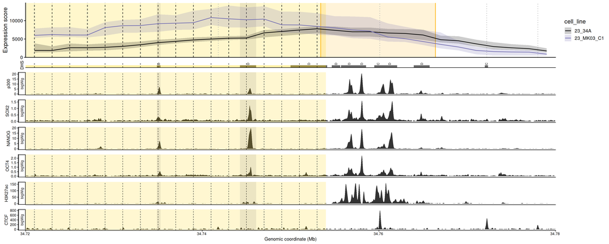

```r
# =============================================================================
# Combine expression score + DHS + ChIP-seq
# =============================================================================

p_expr_DHS_ChIP <- cowplot::plot_grid(

  p_expr_peak,
  p_DHS,

  p_p300,
  p_SOX2,
  p_NANOG,
  p_OCT4,
  p_H3K27ac,
  p_CTCF,

  ncol = 1,

  align = "v",
  axis = "lr",

    rel_heights = c(
    2.2,   # expression score
    0.35,  # DHS
    1,     # p300
    1,     # SOX2
    1,     # NANOG
    1,     # OCT4
    1,     # H3K27ac
    1.35      # CTCF
  )
)


p_expr_DHS_ChIP
```